# 第7回 時系列データ処理（季節性・トレンド除去）

## 水準と前年比

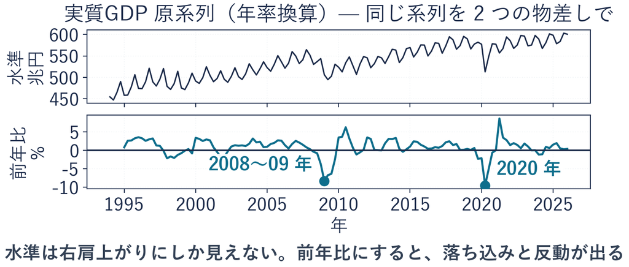

アイス店と同じ読み方。いちばん深い谷は 2020 年 4-6 月期

## ✋ たしかめ 原系列から計算した前年比

たしかめ

原系列のまま計算した前年比は  
公表の季節調整済から計算した前年比と、どれだけ違うか

1. 予想を 1 つ選ぶ：① ほとんど同じ ② 少しずれる ③ まるで違う
2. ヒント：アイス店では、前年比で季節の上下が小さくなった
3. 選んだ理由も、少し考えてみる

⏸ PAUSE 動画を止めて $1$ 分。予想を決めたら再生に戻る

## ★ 原系列の前期比と前年比

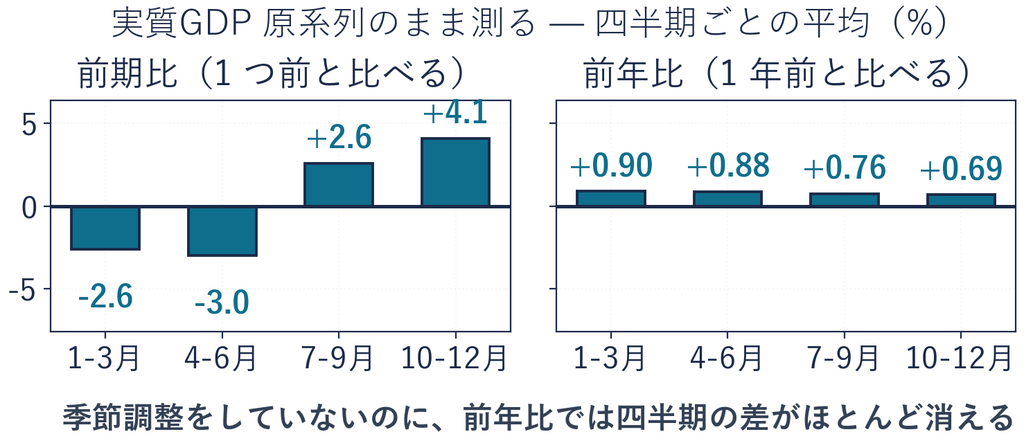

たしかめの答えは **①**。前年比にすると、季節の上下がほぼ消える

## 前年比と季節性

性質

**1 年前の同じ季節と比べるので、季節の影響を弱めやすい**  
**ぴったり消えるのは、季節が毎年同じ倍率で掛かるときだけ**

- **GDP では**：2020 年 4-6 月期は原系列 $-9.46$%・公表 $-9.51$%（差 $0.05$ ポイント）
- **アイス店では**：季節が足し算で乗るので、割る数に季節が残る（15.4〜23.5%）
- **分解との違い**：分解は季節の大きさを見せる。前年比は見せない

弱めるが、消えきるとは限らない。残ったかどうかは、目では言えない

## よくある失敗 前年比の基準の見落とし

✕ 前年比の大きさだけで読む

前年比 $+8.6$% だから好景気

（原系列 $+8.61$%・公表の季節  
調整済 $+8.66$%）

○ 比較の基準がどこかを見る

2021 年 4-6 月期は、前年が底

1 年前の前年比は原系列 $-9.46$%

そこから戻るだけで $+8.6$% になる

「去年と比べて」としか言っていないのに、良く聞こえるから

## 1 本の列と相関係数

- **いまの道具**：相関係数は、2 つの列の組を点にして、向きと強さを 1 つの数にする
- **足りないもの**：季節が残ったかを知りたい線は 1 本。組にする相手の列が無い
- **問い**：1 本の列で、前の自分とどれだけ似ているかを、数で測れないか

[figure not shown]

1 本の列でも、ずらせば 2 本になる

## ① 1 期ずらした組

[figure not shown]

「なし」の期は相手がいないので組にしない。6 組の点から、相関は $-0.07$

## ② 2 期ずらした組

[figure not shown]

半年前の山と谷が組になり、5 組の点は右下がり。相関は $-0.89$

## ◼ 自己相関

**自己相関：ずらした自分との相関係数**

定義

$$\textbf{ラグ } k \textbf{ の自己相関} = \textcolor{#0f7b41}{\textbf{相関係数}}\,(\,y_t,\ \textcolor{#0f6e8c}{y_{t-k}}\,)$$

- 相関係数：2 つの列の組の向きと強さを 1 つの数に（前に出てきた道具）
- $y_{t-k}$：$k$ 期前の値。`shift` で作るラグ変数（このトピックの道具）

自己相関の発想

相関係数は、2 本の列の組で測る

⬇

知りたい線は 1 本しかない

⬇

**ずらした自分を 2 本目にする**

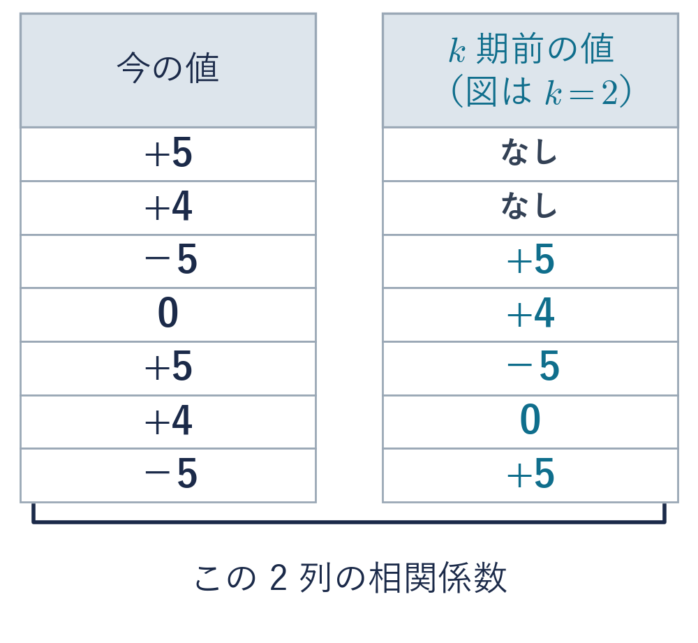

## ③ 3 期ずらした組

[figure not shown]

9 か月前と組にすると、組になる季節がまたばらばら。自己相関は $-0.06$

## ④ 4 期ずらした組

[figure not shown]

1 年前の同じ 3 か月どうしが組。3 組の点は斜めの線に乗り、自己相関は $1.0$

## ◼ コレログラム

**コレログラム：ラグごとの自己相関を棒で並べた図**

**ラグ**：ずらす幅。横に 1, 2, 3, 4 と並べ、縦に自己相関の棒を立てる

[figure not shown]

季節があれば、ラグ 4（1 年前との組）に山が出る。この山が季節の指紋

## ★ コレログラムと季節性

今度は実質 GDP の前期比で、同じ手順を、ずらす幅を 12 まで

[figure not shown]

原系列はラグ 4・8 に山（$+0.87$・$+0.86$）。公表の季節調整済では消える

## ★ 季節の取り残しの確かめ

前のトピックの問い「季節は取り切れたか」を、ラグ 4 の自己相関で測る

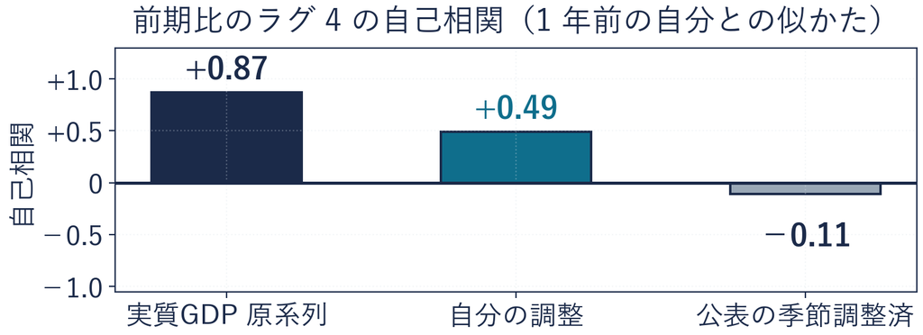

自作は 0.49 で季節が残る。前のトピックで公表系列を選んだ理由が、この数

## 写経 前期比の自己相関

```python
q = y.pct_change() * 100
m = mine.pct_change() * 100
print(q.autocorr(4), m.autocorr(4))
```

| 行 | 部品 | 意味 |
| --- | --- | --- |
| 1 | `pct_change()` | 1 期前と比べた変化率＝前期比（原系列） |
| 2 | `mine.pct_change()` | 自分で季節を引いた線の前期比。変わる部品は列の名前だけ |
| 3 | `autocorr(4)` | 4 期ずらした自分との相関＝ラグ 4 の自己相関 |

※ `mine` は前のトピックの写経で作った、自分で季節を引いた線

## コードセルの写経と実行

1. **＋ コード**で空のセルを足す  
   （案内の文の下）
2. 前のページの写経、  
   3 行を上から写す
3. **▶** か **Shift + Enter** で実行  
   （Mac は Shift + return）
4. セルの下に、  
   2 つの数が出る

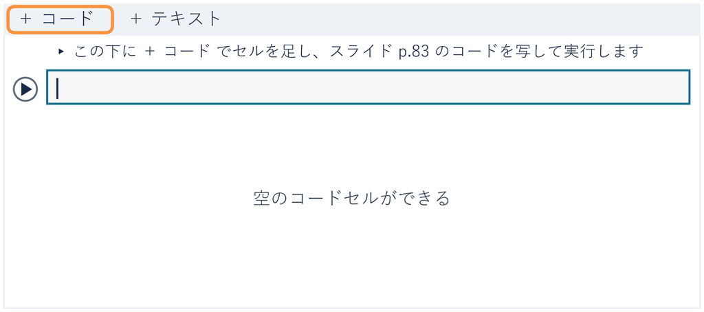

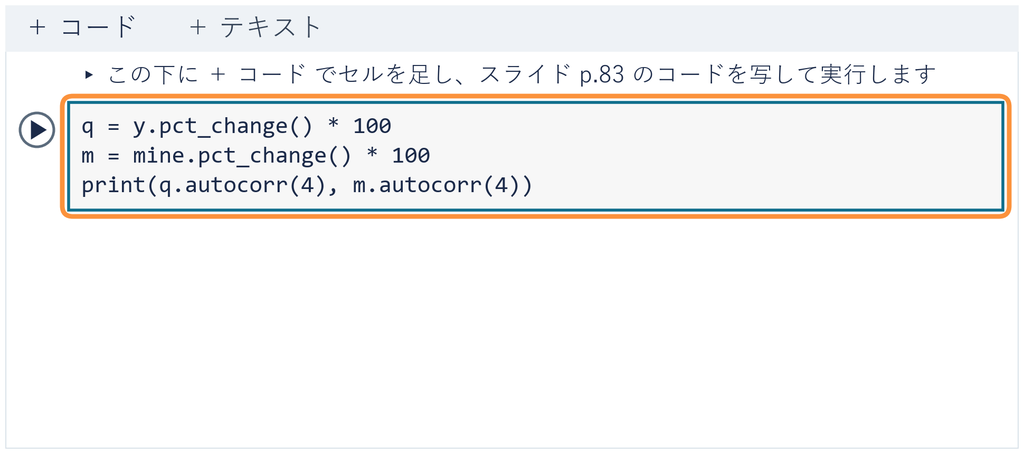

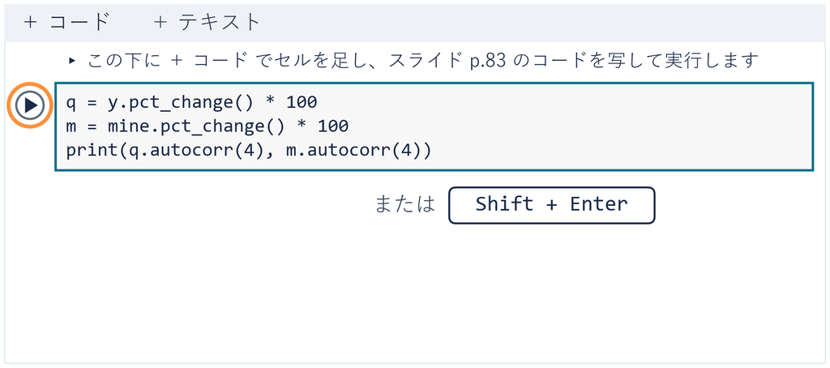

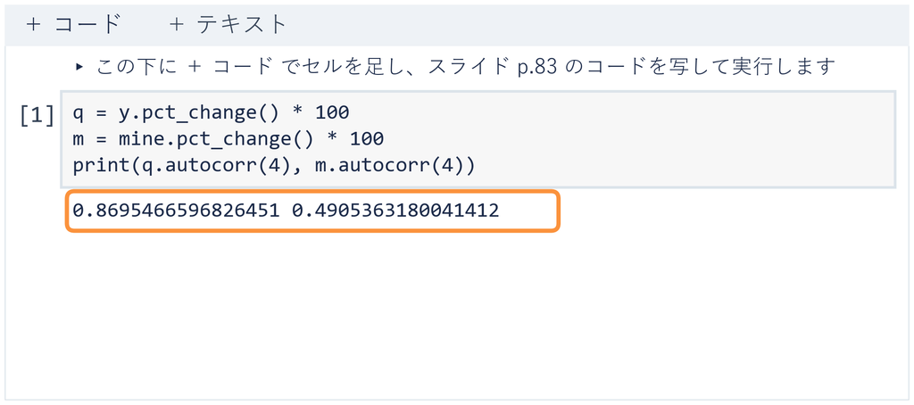

⏸ PAUSE 動画を止めて $2$ 分。2 つの数が出たら再生に戻る

## 演習 7-4 ずらす幅の変更

演習 7-4

2 期ずらすと、似かたはどうなるか

```python
print(q.autocorr(4))
```

1. **先に考える**：ⓐ プラス（同じ向き） ⓑ マイナス（逆の向き）
2. **写して変える**：`autocorr(4)` の 4 を 2 に（1 か所）
3. **終わり**：数が出たら、答え欄に ⓐ か ⓑ・出た数・理由を一言

※ 新しいセルに写す。写したまま実行すると `0.8695…`（前のページの 1 つ目と同じ）

⏸ PAUSE 動画を止めて $3$ 分。答えを書いたら再生に戻る

## 演習 7-4 の答え

答えは **ⓑ マイナス**。2 期ずらすと $-0.72$

| セル | 出力 | 読み方 |
| --- | --- | --- |
| `print(q.autocorr(4))` | `0.8695…` | 1 年前と並ぶ（同じ季節） |
| `print(q.autocorr(2))` | `-0.7213…` | 半年前と並ぶ（山と谷） |

アイス店の 2 期ずらし $-0.89$ と同じ形。ずらす幅で、並ぶ季節が変わる

## 回のまとめ

- 1 本の線を 見る → ならす → 分ける → 選ぶ・確かめる
- 前年比：同じ季節どうしで比べ、分けずに季節を弱める
- 自己相関：$k$ 期ずらした自分との相関。ラグ 4 の山が季節の指紋
- 取り切れたか：原系列 0.87 → 自作 0.49 → 公表 −0.11
- ニュースの数は「前年同期比」か「季節調整済み」かを見て読む

経済の線は、トレンドと季節と残差でできている。  
分けて見ると、何が起きたのかが読める  
過去の値をずらして列にするこの操作は、この先また出てくる